# Enterococci Bacteria in Sydney Northern Beaches

Project 2 (Individual project)

SID - 510545406

University of Sydney | Math1005, S2-RE | Lab Class 3, Wednessday 2PM-3PM

# Executive Summary

Beaches are ideal vacation spots, and as our world continues to industrialise, these water bodies tend to get contaminated. This report focuses on analysing the amount of contamination of faecal matter in Sydney’s Northern beaches.

We analysed the dataset from the viewpoint of two research questions: “Which site in the Sydney Northern Beaches had the highest average Enterococci bacteria?” and “Does the concentration of Enterococci bacteria increase in summer months versus winter months?” The first research question helped identify places of concern, and the second research question was insightful when identifying Enterococci bacteria was at its peak.

# Enterococci Bacteria in Sydney Northern Beaches

## Initial Data Analysis (IDA)

### Source

The source of the data is the NSW Government Office of Environment and Heritage. The data seems to be a valid source collected from the government to analyse Enterococci bacteria in the water for community protection and wellbeing. A possible limitation to the data collected could be selection bias, where populated beaches may have more Enterococci bacteria. Another limitation is omitted variable bias, where the variable of time was not recorded. The high or low tide may affect the accurate sampling process; therefore, the sampling time is an important variable that affects the investigation. Otherwise, the data seems to be trustworthy.

### Stakeholders

The possible stakeholders for this investigation include the NSW government office of environment and heritage and Sydney’s northern beaches council. Furthermore, the data is helpful to NGO’s, sewage companies, septic system manufacturers, fishing and boating companies. Lastly, the investigation is beneficial to the general public visiting these beaches along with tourists.

### Variables

There are ten columns excluding variable ‘X’, which is a row marker. Therefore, there are four quantitative variables: beachID, longitude, latitude, and Enterococci bacteria concentration, while the rest of the six variables are qualitative variables. Each column stands for a variable recorded during the sampling process, for example, the day of the week column stands for the day the water sample was tested and recorded. On the contrary, each row stands for every sampling session recorded, where the first row stands for one sampling session recorded.

```r
## read in data
data = read.csv("data/beaches.csv")
## show classification of variables
str(data)
```

```
## 'data.frame':    1276 obs. of  11 variables:
##  $ X                      : int  1 2 3 4 5 6 7 8 9 10 ...
##  $ BeachId                : num  4 4 4 4 4 4 4 4 4 4 ...
##  $ Region                 : chr  "Sydney Northern Ocean Beaches" "Sydney Northern Ocean Beaches" "Sydney Northern Ocean Beaches" "Sydney Northern Ocean Beaches" ...
##  $ Council                : chr  "Northern Beaches Council" "Northern Beaches Council" "Northern Beaches Council" "Northern Beaches Council" ...
##  $ Site                   : chr  "Avalon Beach" "Avalon Beach" "Avalon Beach" "Avalon Beach" ...
##  $ Longitude              : num  151 151 151 151 151 ...
##  $ Latitude               : num  -33.6 -33.6 -33.6 -33.6 -33.6 ...
##  $ Date                   : chr  "2018-01-25" "2018-02-07" "2018-02-19" "2018-01-19" ...
##  $ Enterococci..cfu.100ml.: int  6 0 1 1 2 0 33 5 0 0 ...
##  $ Month                  : chr  "January" "February" "February" "January" ...
##  $ Day.of.Week            : chr  "Thursday" "Wednesday" "Monday" "Friday" ...
```

The key variables are:

- site: the precise location for water sampling in Sydney’s northern beaches.
- Enterococci..cfu.100ml: The concentration of Enterococci bacteria in 100 millilitres of water.
- Month: The month where the sample of water was collected and tested for bacteria.

During the assessment of the variables, there were three N/A values in the Enterococci bacteria column, which were converted to 0.

```r
##Converting N/A values to 0 for accurate calculation
data[is.na(data)] = 0
```

## Which site in the Sydney Northern Beaches had the highest average Enterococci bacteria?

A bar graph can answer this research question since it focuses on the qualitative variable ‘site’ and the quantitative variable ‘Enterococci bacteria per 100ml’.

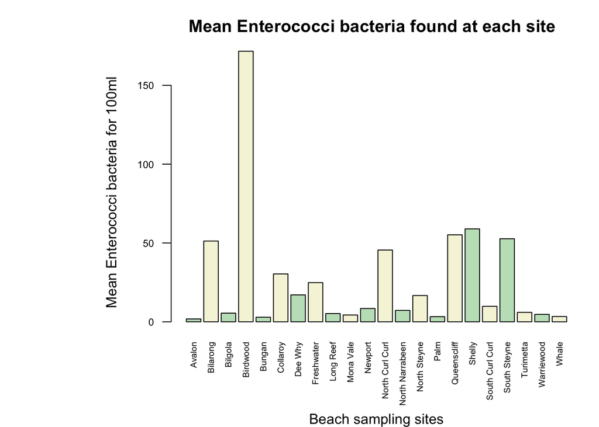

```r
site = data$Site
bacteria = data$Enterococci..cfu.100ml.

##creating a list will all site names
site_names = c('Avalon', 'Bilarong', 'Bilgola', 'Birdwood','Bungan','Collaroy', 'Dee Why', 'Freshwater', 'Long Reef','Mona Vale', 'Newport', 'North Curl Curl', 'North Narrabeen', 'North Steyne', 'Palm', 'Queenscliff', 'Shelly', 'South Curl Curl', 'South Steyne', 'Turimetta', 'Warriewood', 'Whale')

## Calculating the mean for all sites and storing in a list
i = 1
values = list()
while (i <= length(site_names)){
  ##grepl function was found after researching on how to execute this code efficiently
  values[i] = mean(bacteria[grepl(site_names[i], site, fixed = TRUE)])
  i = i+1
}
## generating bar plot
par(mar = c(6, 10, 3, 1))
barplot(unlist(values), names = unlist(site_names), las=2, cex.names=0.6, cex.axis=0.7, col = c("#C1E1C1", "#F5F5DC"), ylab = 'Mean Enterococci bacteria for 100ml', main = "Mean Enterococci bacteria found at each site", adj = 0.4)
title(xlab = 'Beach sampling sites', mgp = c(5, 1, 0))
```

A box plot and numerical summaries were calculated to conduct a more in-depth analysis of the values as a whole.

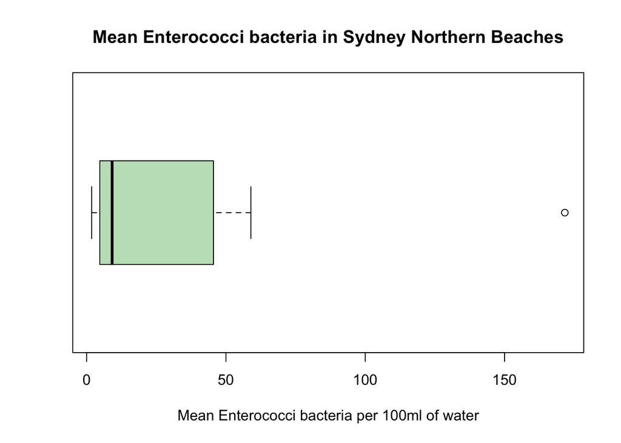

```r
## generating a box plot for Mean Enterococci bacteria
boxplot(unlist(values), horizontal = TRUE, main = "Mean Enterococci bacteria in Sydney Northern Beaches", xlab = "Mean Enterococci bacteria per 100ml of water", col = "#C1E1C1")
```

```r
##calculating numerical summaries for Mean Enterococci bacteria
cat("Numerical Summaries for Mean Enterococci bacteria", "\n", "Mean:", mean(unlist(values)),"\n", "Standard Diviation:", sd(unlist(values)),"\n", "Median:", median(unlist(values)),"\n", "Interquartile Range:", IQR(unlist(values)),"\n")
```

```
## Numerical Summaries for Mean Enterococci bacteria
##  Mean: 26.67085
##  Standard Diviation: 37.98109
##  Median: 9.146552
##  Interquartile Range: 36.87931
```

### Summary

The bar graph shows that Birdwood park beach has the highest mean amount of Enterococci bacteria in 100ml of water and seems to be an outlier, with the average concentration of Enterococci bacteria per 100ml of water being approximately 172.

The mean concentration of Enterococci bacteria per 100ml of water for the rest of the beaches ranges from approximately 2 to 59. The standard deviation is relatively high, indicating the data is more spread out.

### Additional Research

According to guidelines on water quality for Marin and Freshwater [1], if the Enterococci bacteria per 100ml is more than 140, there is a cause for alert, followed by increased monitoring of beaches and an investigation of the source. Birdwood park beach would fall under this category. Since most beaches fall under the category below 140, there is a requirement for routine monitoring of these beaches. Many countries follow these guidelines hence seems to be a valuable source to compare the findings from this investigation.

During the investigation, an article published by the Daily Telegraph [2] revealed three water spots with the most faecal matter in 2017. The article focuses on the year before the data was collected and shows that Birdwood Park beach had high Enterococci bacteria present in the water. However, the time constraint is a limitation to this article. The article talked about two of the beaches investigated, Birdwood and Bilarong and stated that Birdwood was unsuitable for swimming around 20% of the time while Bilarong occasionally exceeded the safety limit.

## Does the concentration of Enterococci bacteria increase in summer months compared to winter months?

The answer to this research question lies in finding the difference between the Enterococci bacteria in the summer months versus the Enterococci bacteria in the winter months and seeing if the difference is usually greater than 0 or equal to 0.

### Significance level

The significance level is $\alpha = 0.05$ by convention.

### Hypothesis

If $\mu$ = mean of the differences between summer months and winter months, the hypothesis to test is $H_0:\mu=0$ vs $H_1:\mu > 0$.

### Assumptions

The first reasonable assumption made is that the concentration of Enterococci bacteria measured per 100ml of water is independent of each other. The second assumption is that the sampling of Enterococci bacteria is normally distributed for applying the Central Limit Theorem on a small sample size. However, this assumption has the possibility of not being satisfied.

### Test statistic

```r
months = data$Month

summer_months = c('December', 'January', 'February')
winter_months = c('June', 'July', 'August')

summer_bacteria = bacteria[months == summer_months]
winter_bacteria = bacteria[months == winter_months]
diff = summer_bacteria - winter_bacteria

t.test(mu = 0, diff, alternative = "greater")
```

```
##
##  One Sample t-test
##
## data:  diff
## t = 0.82986, df = 93, p-value = 0.2044
## alternative hypothesis: true mean is greater than 0
## 95 percent confidence interval:
##  -20.59487       Inf
## sample estimates:
## mean of x
##  20.55319
```

### Summary

The p-value observed is above 0.05 (the significance level), which concludes that the null hypothesis is retained. This also shows that the alternate hypothesis is based on chance and can not be rejected or retained. The data provide little evidence that the summer months have an increase in Enterococci bacteria compared to the winter months. While the increase in bacteria might be a result of the climate, there are multiple confounding factors to consider since correlation does not equal causation. Hot climate may attract more people to the beach, hence more populated beaches may have more bacteria.

# References

[1] LAWA. (2020, November 13). Coastal and freshwater recreation monitoring. Land, Air, Water Aotearoa (LAWA). Retrieved November 2, 2021, from https://www.lawa.org.nz/learn/factsheets/coastal-and-freshwater-recreation-monitoring/

[2] Swain, S. (2017). Three waterspots have ‘faecal matter’ as best beaches … The Daily Telegraph. Retrieved November 2, 2021, from https://www.dailytelegraph.com.au/newslocal/manly-daily/three-waterspots-have-faecal-matter-as-best-beaches-revealed/news-story/82caf250ab7a7d5b78c6a76c9b1d20ce.